# project2

## Ames Housing Data and Kaggle Challenge

### Problem Statement:

When it comes to predicting the sale price of a house, there are so many factors to consider. From the obvious, such as the number of bedrooms, year built, and proximity to schools or rural areas, to the less obvious, such as existance of garage, there are a multitude of variables that can affect the sale price. This makes it extremely difficult to accurately predict the value of a home.

Realtors and prospective home-buyers need a way to rank the most important factors affecting sale price in order to maximize the value of the home they are trying to buy or sell. Manually trying to weigh each of these factors against each other would be a time-consuming process, which is why machine learning can be a great tool to use.

Regression analysis is a mathematical method that can be used to identify the most important factors in predicting sale price. In this case, sale price is the dependent variable, and the other factors are independent variables.

### Importing libraries

```python
import pandas as pd
import numpy as np
import seaborn as sns
import matplotlib.pyplot as plt
from sklearn.model_selection import train_test_split, cross_val_score, GridSearchCV
from sklearn.linear_model import LinearRegression, Ridge, RidgeCV, Lasso, LassoCV, ElasticNet, ElasticNetCV, LogisticRegression
from sklearn.preprocessing import StandardScaler, PolynomialFeatures, OneHotEncoder
from sklearn import metrics
from sklearn.metrics import r2_score, mean_squared_error

from sklearn.pipeline import Pipeline, make_pipeline
```

### Read and Load the Data

```python
# Import all our data
train = pd.read_csv('../datasets/train.csv')
test = pd.read_csv('../datasets/test.csv')
sample = pd.read_csv('../datasets/sample_sub_reg.csv')
```

### Explore the data

```python
print('Print the shape of Train, Test, Sample datasets', train.shape, test.shape, sample.shape)
```

```
Print the shape of Train, Test, Sample datasets (2051, 81) (878, 80) (878, 2)
```

```python
train.info()
```

```
<class 'pandas.core.frame.DataFrame'>
RangeIndex: 2051 entries, 0 to 2050
Data columns (total 81 columns):
 #   Column           Non-Null Count  Dtype
---  ------           --------------  -----
 0   Id               2051 non-null   int64
 1   PID              2051 non-null   int64
 2   MS SubClass      2051 non-null   int64
 3   MS Zoning        2051 non-null   object
 4   Lot Frontage     1721 non-null   float64
 5   Lot Area         2051 non-null   int64
 6   Street           2051 non-null   object
 7   Alley            140 non-null    object
 8   Lot Shape        2051 non-null   object
 9   Land Contour     2051 non-null   object
```

[output cut: 73 more lines]

```python
# Explore the train dataset
train.head(2)
```

|  | Id | PID | MS SubClass | MS Zoning | Lot Frontage | Lot Area | Street | Alley | Lot Shape | Land Contour | ... | Screen Porch | Pool Area | Pool QC | Fence | Misc Feature | Misc Val | Mo Sold | Yr Sold | Sale Type | SalePrice |
| --- | --- | --- | --- | --- | --- | --- | --- | --- | --- | --- | --- | --- | --- | --- | --- | --- | --- | --- | --- | --- | --- |
| 0 | 109 | 533352170 | 60 | RL | NaN | 13517 | Pave | NaN | IR1 | Lvl | ... | 0 | 0 | NaN | NaN | NaN | 0 | 3 | 2010 | WD | 130500 |
| 1 | 544 | 531379050 | 60 | RL | 43.0 | 11492 | Pave | NaN | IR1 | Lvl | ... | 0 | 0 | NaN | NaN | NaN | 0 | 4 | 2009 | WD | 220000 |

2 rows × 81 columns

To help process the exploratory data analysis (EDA), I used a variety of functions. These included functions such as summary statistics, plotting, and correlation analysis. I also used functions such as filtering, grouping, and sorting to help organize the data. Additionally, I used functions such as predictive modeling to help identify patterns and trends in the data. By combining these functions, I was able to gain a better understanding of the data and draw meaningful conclusions from it.

```python
# take column name and update with lower and underscore if there is any space
def update_column(col):

    new_col = ''
    for c in col.strip().lower():
        if c.isalnum():
            new_col += c
        elif c == ' ':
            new_col += '_'
        elif c == '-':
            new_col += '_'
    return new_col

# Taking list of column and return dict of old and new column
def column_dict(col):

    new_col = {}
    for k in col:
        val = update_column(k)
        new_col[k] = val

    return new_col

# Taking dataset and return updated columns.
# the function should be called with dataset as arg to return updated columns.
def column_rename(dataset):

    old_cols = dataset.columns
    new_dict = column_dict(old_cols)
    dataset.rename(columns = new_dict, inplace=True)
    return dataset.columns

# Return more than 25% of the column data that is null
def null_shape(dataset):
    data_len = dataset.shape[0]
    null_data = {}
    # Loop through the column and check if the column has null value more than 25% of row value
    for data in dataset:
        if dataset[data].isnull().sum() > 0.25 * data_len:
            null_data[data] = dataset[data].isnull().sum()
    return null_data

# fill row with a given value
def fill_row(dataset, col, val):

    dataset[col] = dataset[col].fillna(val)
    return
def fill_category(dataset, val):

    for data in dataset:
        dataset[data] = dataset[data].fillna(val)
    return

# high correlation filter (> 0.5) for dataset that has independent variables
def high_corr(dataset, lim):

    highly_corr = []
    datacorr = dataset.corr()
    filtered = datacorr[((datacorr >= lim) | (datacorr <= -lim)) & (datacorr !=1.00)]
    filtered = filtered.unstack().sort_values(ascending=False).drop_duplicates()
    m = 0
    data_col =  dataset.columns
    data_len =  len(data_col)
    for data in dataset:
        m += 1
        for i in range(data_len):
            n = i + m
            if n < data_len:
                col_name = data_col[n]
                cor = dataset[data].corr(dataset[col_name])
                if cor >= lim:
                    if data not in highly_corr:
                        highly_corr.append(data)
                    if col_name not in highly_corr:
                        highly_corr.append(col_name)
    print(highly_corr)
    return highly_corr, filtered

# print(train_numerical[train_numerical['mas_vnr_area'].isnull()].index.tolist())
```

```python
# Rename columns for easy use (column_rename performs each column to lower case, remove white space and replace empty spaces in words to underscore.
train_columns = column_rename(train)
train_columns
```

```
Index(['id', 'pid', 'ms_subclass', 'ms_zoning', 'lot_frontage', 'lot_area',
       'street', 'alley', 'lot_shape', 'land_contour', 'utilities',
       'lot_config', 'land_slope', 'neighborhood', 'condition_1',
       'condition_2', 'bldg_type', 'house_style', 'overall_qual',
       'overall_cond', 'year_built', 'year_remodadd', 'roof_style',
       'roof_matl', 'exterior_1st', 'exterior_2nd', 'mas_vnr_type',
       'mas_vnr_area', 'exter_qual', 'exter_cond', 'foundation', 'bsmt_qual',
       'bsmt_cond', 'bsmt_exposure', 'bsmtfin_type_1', 'bsmtfin_sf_1',
       'bsmtfin_type_2', 'bsmtfin_sf_2', 'bsmt_unf_sf', 'total_bsmt_sf',
       'heating', 'heating_qc', 'central_air', 'electrical', '1st_flr_sf',
       '2nd_flr_sf', 'low_qual_fin_sf', 'gr_liv_area', 'bsmt_full_bath',
       'bsmt_half_bath', 'full_bath', 'half_bath', 'bedroom_abvgr',
       'kitchen_abvgr', 'kitchen_qual', 'totrms_abvgrd', 'functional',
       'fireplaces', 'fireplace_qu', 'garage_type', 'garage_yr_blt',
       'garage_finish', 'garage_cars', 'garage_area', 'garage_qual',
       'garage_cond', 'paved_drive', 'wood_deck_sf', 'open_porch_sf',
       'enclosed_porch', '3ssn_porch', 'screen_porch', 'pool_area', 'pool_qc',
       'fence', 'misc_feature', 'misc_val', 'mo_sold', 'yr_sold', 'sale_type',
       'saleprice'],
      dtype='object')
```

```python
# Rename columns for easy use (column_rename performs each column to lower case, remove white space and replace empty spaces in words to underscore.
sample_columns = column_rename(sample)
sample_columns
```

```
Index(['id', 'saleprice'], dtype='object')
```

```python
# Rename columns for easy use (column_rename performs each column to lower case, remove white space and replace empty spaces in words to underscore.
test_columns = column_rename(test)
test_columns
```

```
Index(['id', 'pid', 'ms_subclass', 'ms_zoning', 'lot_frontage', 'lot_area',
       'street', 'alley', 'lot_shape', 'land_contour', 'utilities',
       'lot_config', 'land_slope', 'neighborhood', 'condition_1',
       'condition_2', 'bldg_type', 'house_style', 'overall_qual',
       'overall_cond', 'year_built', 'year_remodadd', 'roof_style',
       'roof_matl', 'exterior_1st', 'exterior_2nd', 'mas_vnr_type',
       'mas_vnr_area', 'exter_qual', 'exter_cond', 'foundation', 'bsmt_qual',
       'bsmt_cond', 'bsmt_exposure', 'bsmtfin_type_1', 'bsmtfin_sf_1',
       'bsmtfin_type_2', 'bsmtfin_sf_2', 'bsmt_unf_sf', 'total_bsmt_sf',
       'heating', 'heating_qc', 'central_air', 'electrical', '1st_flr_sf',
       '2nd_flr_sf', 'low_qual_fin_sf', 'gr_liv_area', 'bsmt_full_bath',
       'bsmt_half_bath', 'full_bath', 'half_bath', 'bedroom_abvgr',
       'kitchen_abvgr', 'kitchen_qual', 'totrms_abvgrd', 'functional',
       'fireplaces', 'fireplace_qu', 'garage_type', 'garage_yr_blt',
       'garage_finish', 'garage_cars', 'garage_area', 'garage_qual',
       'garage_cond', 'paved_drive', 'wood_deck_sf', 'open_porch_sf',
       'enclosed_porch', '3ssn_porch', 'screen_porch', 'pool_area', 'pool_qc',
       'fence', 'misc_feature', 'misc_val', 'mo_sold', 'yr_sold', 'sale_type'],
      dtype='object')
```

```python
train.shape, test.shape, sample.shape
```

```
((2051, 81), (878, 80), (878, 2))
```

##### Verify the Null values

```python
print('Total number of null values from of Train, Test, Sample datasets', train.isna().sum().sum(), test.isna().sum().sum(), sample.isna().sum().sum())
```

```
Total number of null values from of Train, Test, Sample datasets 9822 4171 0
```

```python
# Get detail information of the train columns for missing, corupted, unique size of the columns
train_insight = pd.DataFrame({'dtype': train.dtypes, 'null': train.isnull().sum().values,
                              'unique': train.nunique(), 'zero': (train==0).sum().values})
train_insight.T
```

|  | id | pid | ms_subclass | ms_zoning | lot_frontage | lot_area | street | alley | lot_shape | land_contour | ... | screen_porch | pool_area | pool_qc | fence | misc_feature | misc_val | mo_sold | yr_sold | sale_type | saleprice |
| --- | --- | --- | --- | --- | --- | --- | --- | --- | --- | --- | --- | --- | --- | --- | --- | --- | --- | --- | --- | --- | --- |
| dtype | int64 | int64 | int64 | object | float64 | int64 | object | object | object | object | ... | int64 | int64 | object | object | object | int64 | int64 | int64 | object | int64 |
| null | 0 | 0 | 0 | 0 | 330 | 0 | 0 | 1911 | 0 | 0 | ... | 0 | 0 | 2042 | 1651 | 1986 | 0 | 0 | 0 | 0 | 0 |
| unique | 2051 | 2051 | 16 | 7 | 118 | 1476 | 2 | 2 | 4 | 4 | ... | 100 | 10 | 4 | 4 | 5 | 28 | 12 | 5 | 9 | 828 |
| zero | 0 | 0 | 0 | 0 | 0 | 0 | 0 | 0 | 0 | 0 | ... | 1870 | 2042 | 0 | 0 | 0 | 1986 | 0 | 0 | 0 | 0 |

4 rows × 81 columns

### Cleaning and EDA of numerical and categorical features

```python
# Check if train dataset has more than 25% null value
null_train = null_shape(train)
null_train
```

```
{'alley': 1911,
 'fireplace_qu': 1000,
 'pool_qc': 2042,
 'fence': 1651,
 'misc_feature': 1986}
```

```python
# Get detail information of the test columns for missing, corupted, unique size of the columns
test_insight = pd.DataFrame({'dtype': test.dtypes, 'null': test.isnull().sum().values, 'unique': test.nunique()})
test_insight.T
```

|  | id | pid | ms_subclass | ms_zoning | lot_frontage | lot_area | street | alley | lot_shape | land_contour | ... | 3ssn_porch | screen_porch | pool_area | pool_qc | fence | misc_feature | misc_val | mo_sold | yr_sold | sale_type |
| --- | --- | --- | --- | --- | --- | --- | --- | --- | --- | --- | --- | --- | --- | --- | --- | --- | --- | --- | --- | --- | --- |
| dtype | int64 | int64 | int64 | object | float64 | int64 | object | object | object | object | ... | int64 | int64 | int64 | object | object | object | int64 | int64 | int64 | object |
| null | 0 | 0 | 0 | 0 | 160 | 0 | 0 | 820 | 0 | 0 | ... | 0 | 0 | 0 | 874 | 706 | 837 | 0 | 0 | 0 | 0 |
| unique | 878 | 878 | 15 | 6 | 104 | 689 | 2 | 2 | 4 | 4 | ... | 12 | 54 | 5 | 2 | 4 | 3 | 21 | 12 | 5 | 10 |

3 rows × 80 columns

```python
# Check if train dataset has more than 25% null value and additional columns such as roof_matl, and roof_style
null_test = null_shape(test)
null_test
```

```
{'alley': 820,
 'fireplace_qu': 422,
 'pool_qc': 874,
 'fence': 706,
 'misc_feature': 837}
```

```python
# The null columns for both train and test are the same and may need to drop them.
# After carefully viewed the garage Yr Blt, it's added to be dropped.
col_to_drop = ['alley', 'fireplace_qu', 'pool_qc', 'fence', 'misc_feature', 'garage_yr_blt', 'roof_style','roof_matl','ms_zoning', 'utilities', 'neighborhood','condition_2','exterior_1st','exterior_2nd', 'mas_vnr_type', 'bsmt_cond', 'heating', 'heating_qc','kitchen_qual','functional','garage_qual','sale_type']
train.drop(columns = col_to_drop, axis=1, inplace=True)
test.drop(columns = col_to_drop, axis=1, inplace=True)

print('Train data: ', train.shape, ' Test data: ', test.shape)
```

```
Train data:  (2051, 59)  Test data:  (878, 58)
```

```python
# Differentiate categorical and numerical columns.
train_numerical = train.select_dtypes(include='number')
train_categorical = train.select_dtypes(exclude='number')
```

```python
train_numerical.shape, train_categorical.shape
```

```
((2051, 38), (2051, 21))
```

```python
# Differentiate categorical and numerical columns.
test_numerical = test.select_dtypes(include='number')
test_categorical = test.select_dtypes(exclude='number')
```

```python
test_numerical.shape, test_categorical.shape
```

```
((878, 37), (878, 21))
```

```python
train_numerical.describe()
```

|  | id | pid | ms_subclass | lot_frontage | lot_area | overall_qual | overall_cond | year_built | year_remodadd | mas_vnr_area | ... | wood_deck_sf | open_porch_sf | enclosed_porch | 3ssn_porch | screen_porch | pool_area | misc_val | mo_sold | yr_sold | saleprice |
| --- | --- | --- | --- | --- | --- | --- | --- | --- | --- | --- | --- | --- | --- | --- | --- | --- | --- | --- | --- | --- | --- |
| count | 2051.000000 | 2.051000e+03 | 2051.000000 | 1721.000000 | 2051.000000 | 2051.000000 | 2051.000000 | 2051.000000 | 2051.000000 | 2029.000000 | ... | 2051.000000 | 2051.000000 | 2051.000000 | 2051.000000 | 2051.000000 | 2051.000000 | 2051.000000 | 2051.000000 | 2051.000000 | 2051.000000 |
| mean | 1474.033642 | 7.135900e+08 | 57.008776 | 69.055200 | 10065.208191 | 6.112140 | 5.562165 | 1971.708922 | 1984.190151 | 99.695909 | ... | 93.833740 | 47.556802 | 22.571916 | 2.591419 | 16.511458 | 2.397855 | 51.574354 | 6.219893 | 2007.775719 | 181469.701609 |
| std | 843.980841 | 1.886918e+08 | 42.824223 | 23.260653 | 6742.488909 | 1.426271 | 1.104497 | 30.177889 | 21.036250 | 174.963129 | ... | 128.549416 | 66.747241 | 59.845110 | 25.229615 | 57.374204 | 37.782570 | 573.393985 | 2.744736 | 1.312014 | 79258.659352 |
| min | 1.000000 | 5.263011e+08 | 20.000000 | 21.000000 | 1300.000000 | 1.000000 | 1.000000 | 1872.000000 | 1950.000000 | 0.000000 | ... | 0.000000 | 0.000000 | 0.000000 | 0.000000 | 0.000000 | 0.000000 | 0.000000 | 1.000000 | 2006.000000 | 12789.000000 |
| 25% | 753.500000 | 5.284581e+08 | 20.000000 | 58.000000 | 7500.000000 | 5.000000 | 5.000000 | 1953.500000 | 1964.500000 | 0.000000 | ... | 0.000000 | 0.000000 | 0.000000 | 0.000000 | 0.000000 | 0.000000 | 0.000000 | 4.000000 | 2007.000000 | 129825.000000 |
| 50% | 1486.000000 | 5.354532e+08 | 50.000000 | 68.000000 | 9430.000000 | 6.000000 | 5.000000 | 1974.000000 | 1993.000000 | 0.000000 | ... | 0.000000 | 27.000000 | 0.000000 | 0.000000 | 0.000000 | 0.000000 | 0.000000 | 6.000000 | 2008.000000 | 162500.000000 |
| 75% | 2198.000000 | 9.071801e+08 | 70.000000 | 80.000000 | 11513.500000 | 7.000000 | 6.000000 | 2001.000000 | 2004.000000 | 161.000000 | ... | 168.000000 | 70.000000 | 0.000000 | 0.000000 | 0.000000 | 0.000000 | 0.000000 | 8.000000 | 2009.000000 | 214000.000000 |
| max | 2930.000000 | 9.241520e+08 | 190.000000 | 313.000000 | 159000.000000 | 10.000000 | 9.000000 | 2010.000000 | 2010.000000 | 1600.000000 | ... | 1424.000000 | 547.000000 | 432.000000 | 508.000000 | 490.000000 | 800.000000 | 17000.000000 | 12.000000 | 2010.000000 | 611657.000000 |

8 rows × 38 columns

```python
train_numerical.isna().sum()[:10]
```

```
id                 0
pid                0
ms_subclass        0
lot_frontage     330
lot_area           0
overall_qual       0
overall_cond       0
year_built         0
year_remodadd      0
mas_vnr_area      22
dtype: int64
```

```python
# 'lot_frontage' = Frontage lot null value could be houses with no lot frontage and fill it with zero.
# 'mas_vnr_area' = Masonry veneer area in square feet. Fill the null sqft area to 0 as well.
# 'bsmtfin_sf_1' = Type 1 finished square feet. Fill the null sqft area to 0 as well.
# 'bsmtfin_sf_2' = Rating of basement finished area (if multiple types). Fill the null sqft area to 0 as well.
# 'bsmt_unf_sf' = Unfinished square feet of basement area. Fill the null sqft area to 0 as well.
# 'total_bsmt_sf' = Total square feet of basement area. Fill the null sqft area to 0 as well.
# 'garage_cars' = Size of garage in car capacity. fill 0 if null garage cars
# 'garage_area' = Size of garage in square feet. fill 0 if size of garage is 0 feet.

fill_nazero = ['lot_frontage', 'mas_vnr_area', 'bsmtfin_sf_1', 'bsmtfin_sf_2', 'bsmt_unf_sf', 'total_bsmt_sf', 'bsmt_full_bath','bsmt_half_bath', 'garage_cars', 'garage_area']
for coll in fill_nazero:
    fill_row(train_numerical, coll, 0)
    print(train_numerical[coll].isna().sum())
```

```
0
0
0
0
0
0
0
0
0
0
```

```python
train_numerical.isna().sum().any()
```

```
False
```

```python
train_numerical.count()[:5]
```

```
id              2051
pid             2051
ms_subclass     2051
lot_frontage    2051
lot_area        2051
dtype: int64
```

```python
test_numerical.isna().sum()[:10]
```

```
id                 0
pid                0
ms_subclass        0
lot_frontage     160
lot_area           0
overall_qual       0
overall_cond       0
year_built         0
year_remodadd      0
mas_vnr_area       1
dtype: int64
```

```python
fill_nazero = ['lot_frontage', 'mas_vnr_area']
for coll in fill_nazero:
    fill_row(test_numerical, coll, 0)
    print(test_numerical[coll].isna().sum())
```

```
0
0
```

```python
test_numerical.count()[:5]
```

```
id              878
pid             878
ms_subclass     878
lot_frontage    878
lot_area        878
dtype: int64
```

I created a correlation function to verify the correlation between each feature. I attempted to find the best correlated features that had a correlation ratio of greater than 0.5 and printed out those features.

```python
#train_numerical
filter_high_corr = high_corr(train_numerical, 0.5)
filter_high_corr[1]
```

```
['overall_qual', 'year_built', 'year_remodadd', 'total_bsmt_sf', 'gr_liv_area', 'full_bath', 'garage_cars', 'garage_area', 'saleprice', 'mas_vnr_area', 'bsmtfin_sf_1', 'bsmt_full_bath', '1st_flr_sf', '2nd_flr_sf', 'half_bath', 'bedroom_abvgr', 'totrms_abvgrd']
```

```
garage_area    garage_cars       0.893442
gr_liv_area    totrms_abvgrd     0.813333
total_bsmt_sf  1st_flr_sf        0.808351
saleprice      overall_qual      0.800207
               gr_liv_area       0.697038
totrms_abvgrd  bedroom_abvgr     0.655439
garage_area    saleprice         0.649897
saleprice      garage_cars       0.647781
bsmtfin_sf_1   bsmt_full_bath    0.645697
gr_liv_area    2nd_flr_sf        0.639092
saleprice      total_bsmt_sf     0.629303
year_remodadd  year_built        0.629116
saleprice      1st_flr_sf        0.618486
full_bath      gr_liv_area       0.617323
half_bath      2nd_flr_sf        0.614656
overall_qual   year_built        0.602964
               garage_cars       0.587447
year_remodadd  overall_qual      0.584654
2nd_flr_sf     totrms_abvgrd     0.575327
saleprice      year_built        0.571849
overall_qual   gr_liv_area       0.566701
garage_area    overall_qual      0.563904
gr_liv_area    1st_flr_sf        0.562441
saleprice      year_remodadd     0.550370
total_bsmt_sf  overall_qual      0.549407
year_built     garage_cars       0.543313
total_bsmt_sf  bsmtfin_sf_1      0.539251
saleprice      full_bath         0.537969
full_bath      totrms_abvgrd     0.519630
               overall_qual      0.515080
bedroom_abvgr  gr_liv_area       0.507579
totrms_abvgrd  saleprice         0.504014
saleprice      mas_vnr_area      0.503579
2nd_flr_sf     bedroom_abvgr     0.503394
yr_sold        id               -0.975747
id             id                     NaN
dtype: float64
```

The features that had a correlation ratio of less than 0.5 were dropped. The result of this correlation function is the list of features that are correlated, along with the ratio of correlation between the two features. After careful review, the remaining features were dropped.

```python
# Order the columns based on the original dataset
corr_numerical_train = pd.DataFrame()
corr_numerical_train['id'] = train_numerical['id']
for data in train_numerical:
    if data in filter_high_corr[0]:
        corr_numerical_train[data] = train_numerical[data]
```

```python
# Do the same ordering the columns based on the test dataset
corr_numerical_test = pd.DataFrame()
corr_numerical_test['id'] = test_numerical['id']
col_to_add = filter_high_corr[0]
# remove sale price column
col_to_add.remove('saleprice')
for data in test_numerical:
    if data in col_to_add:
        corr_numerical_test[data] = test_numerical[data]
```

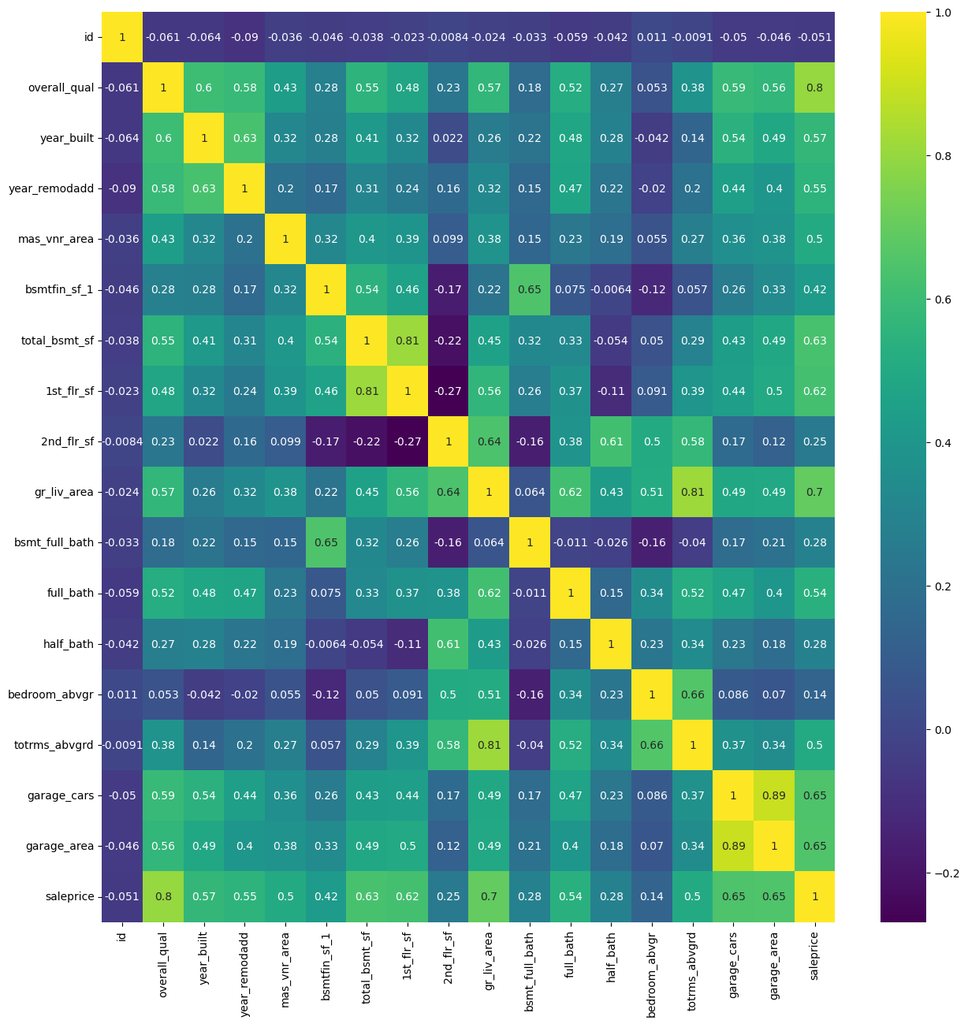

```python
# Plot heatmap to show the correlaton among the numerical data as well as with the target column sale price
plt.figure(figsize = (15, 15))
sns.heatmap(corr_numerical_train.corr(), cmap='viridis', annot=True)
plt.show();
```

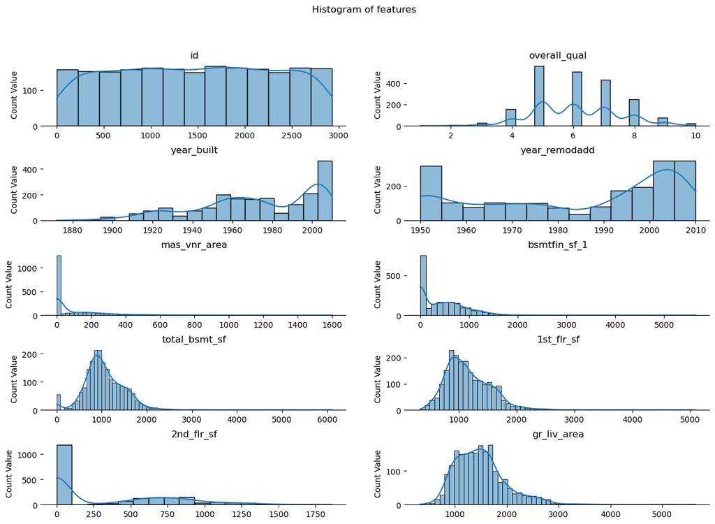

```python
# Set up the figure
col_num = 2
row_num = 5
fig, axis = plt.subplots(row_num, col_num, figsize=(15, 10)) #, sharex=True)
fig.suptitle('Histogram of features ')
sns.despine(left=True)
plt.subplots_adjust(hspace = .5)

for row in range(row_num):
    for col in range(col_num):
        rowx = row*2+col
        ax=axis[row,col]
        ax.set_title(corr_numerical_train.iloc[:,rowx].name)
        sns.histplot(corr_numerical_train.iloc[:,rowx], kde=True, ax=ax)
        ax.set_xlabel('')
        ax.set_ylabel('Count Value');
```

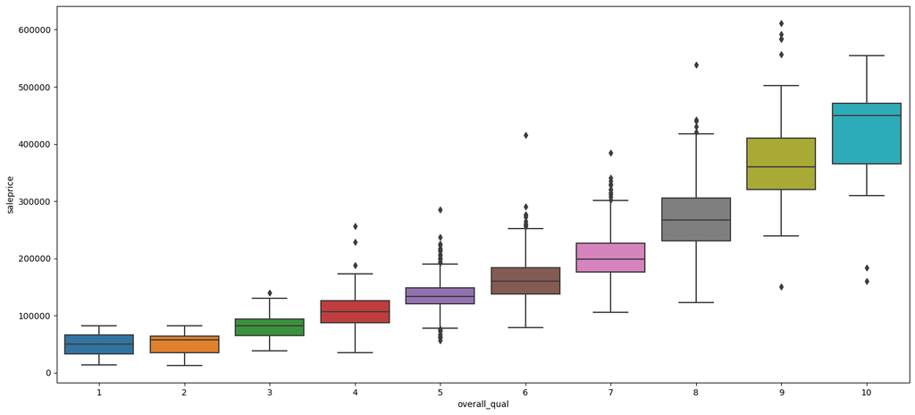

```python
plt.figure(figsize=(18, 8))
sns.boxplot(x=corr_numerical_train['overall_qual'], y=corr_numerical_train['saleprice'], data=corr_numerical_train);
```

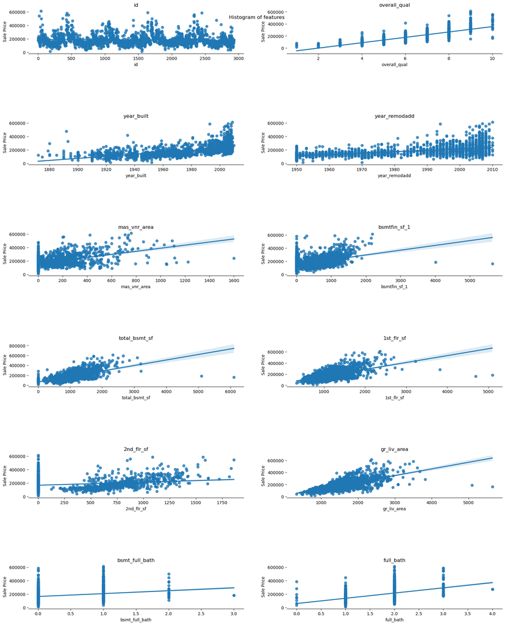

```python
# Set up the figure
col_num = 2
row_num = 6
sale_column = corr_numerical_train['saleprice']
fig, axis = plt.subplots(row_num, col_num, figsize=(20, 20))
fig.suptitle('Histogram of features ')
sns.despine(left=True)
plt.subplots_adjust(hspace = .5)
plt.subplots_adjust(top = 0.99, bottom=0.01, hspace=1.5, wspace=0.2)
for row in range(row_num):
    for col in range(col_num):
        rowx = row*2+col
        col_name = corr_numerical_train.iloc[:,rowx].name
        ax=axis[row,col]
        ax.set_title(col_name)
        if corr_numerical_train.iloc[:,rowx].dtype == 'float64':
            sns.regplot(x=corr_numerical_train.iloc[:,rowx], y=sale_column, data=corr_numerical_train, ax=ax)
        else:
            #sns.boxplot(x=corr_numerical_train.iloc[:,rowx], y=sale_column, data=corr_numerical_train, ax=ax)
            sns.regplot(x=corr_numerical_train.iloc[:,rowx], y=sale_column, data=corr_numerical_train, ax=ax)
        ax.set_xlabel(col_name)
        ax.set_ylabel('Sale Price');
```

```python
count= 0
for data in train_categorical:
    if train_categorical[data].isna().any():
        count += 1
print(f'Number of categorical column :{len(train_categorical.columns)} | Columns with Null: {count} | Total number of categorical Null values: {sum(train_categorical.isna().sum().values)}')
print('========')
for col in train_categorical:
    print(f'Column: {col} | Null: {train_categorical[col].isna().any()}| Null Count: {train_categorical[col].isna().sum()} | Unique : {len(train_categorical[col].unique())}')
```

```
Number of categorical column :21 | Columns with Null: 7 | Total number of categorical Null values: 565
========
Column: street | Null: False| Null Count: 0 | Unique : 2
Column: lot_shape | Null: False| Null Count: 0 | Unique : 4
Column: land_contour | Null: False| Null Count: 0 | Unique : 4
Column: lot_config | Null: False| Null Count: 0 | Unique : 5
Column: land_slope | Null: False| Null Count: 0 | Unique : 3
Column: condition_1 | Null: False| Null Count: 0 | Unique : 9
Column: bldg_type | Null: False| Null Count: 0 | Unique : 5
Column: house_style | Null: False| Null Count: 0 | Unique : 8
Column: exter_qual | Null: False| Null Count: 0 | Unique : 4
Column: exter_cond | Null: False| Null Count: 0 | Unique : 5
Column: foundation | Null: False| Null Count: 0 | Unique : 6
Column: bsmt_qual | Null: True| Null Count: 55 | Unique : 6
Column: bsmt_exposure | Null: True| Null Count: 58 | Unique : 5
Column: bsmtfin_type_1 | Null: True| Null Count: 55 | Unique : 7
Column: bsmtfin_type_2 | Null: True| Null Count: 56 | Unique : 7
Column: central_air | Null: False| Null Count: 0 | Unique : 2
Column: electrical | Null: False| Null Count: 0 | Unique : 5
Column: garage_type | Null: True| Null Count: 113 | Unique : 7
Column: garage_finish | Null: True| Null Count: 114 | Unique : 4
Column: garage_cond | Null: True| Null Count: 114 | Unique : 6
Column: paved_drive | Null: False| Null Count: 0 | Unique : 3
```

```python
# Replace the Null values with None
fill_category(train_categorical, 'None')
```

```python
count= 0
for data in train_categorical:
    if train_categorical[data].isna().any():
        count += 1
print('Null values after cleaning')
print('--------------------------')
print(f'Number of categorical column :{len(train_categorical.columns)} | Columns with Null: {count} | Total number of categorical Null values: {sum(train_categorical.isna().sum().values)}')
```

```
Null values after cleaning
--------------------------
Number of categorical column :21 | Columns with Null: 0 | Total number of categorical Null values: 0
```

```python
# Replace the Null values with None
fill_category(test_categorical, 'None')
```

```python
count= 0
for data in test_categorical:
    if test_categorical[data].isna().any():
        count += 1
print('Null values after cleaning')
print('--------------------------')
print(f'Number of categorical column :{len(test_categorical.columns)} | Columns with Null: {count} | Total number of categorical Null values: {sum(test_categorical.isna().sum().values)}')
```

```
Null values after cleaning
--------------------------
Number of categorical column :21 | Columns with Null: 0 | Total number of categorical Null values: 0
```

```python
train_categorical
```

|  | street | lot_shape | land_contour | lot_config | land_slope | condition_1 | bldg_type | house_style | exter_qual | exter_cond | ... | bsmt_qual | bsmt_exposure | bsmtfin_type_1 | bsmtfin_type_2 | central_air | electrical | garage_type | garage_finish | garage_cond | paved_drive |
| --- | --- | --- | --- | --- | --- | --- | --- | --- | --- | --- | --- | --- | --- | --- | --- | --- | --- | --- | --- | --- | --- |
| 0 | Pave | IR1 | Lvl | CulDSac | Gtl | RRAe | 1Fam | 2Story | Gd | TA | ... | TA | No | GLQ | Unf | Y | SBrkr | Attchd | RFn | TA | Y |
| 1 | Pave | IR1 | Lvl | CulDSac | Gtl | Norm | 1Fam | 2Story | Gd | TA | ... | Gd | No | GLQ | Unf | Y | SBrkr | Attchd | RFn | TA | Y |
| 2 | Pave | Reg | Lvl | Inside | Gtl | Norm | 1Fam | 1Story | TA | Gd | ... | TA | No | GLQ | Unf | Y | SBrkr | Detchd | Unf | TA | Y |
| 3 | Pave | Reg | Lvl | Inside | Gtl | Norm | 1Fam | 2Story | TA | TA | ... | Gd | No | Unf | Unf | Y | SBrkr | BuiltIn | Fin | TA | Y |
| 4 | Pave | IR1 | Lvl | Inside | Gtl | Norm | 1Fam | 1.5Fin | TA | TA | ... | Fa | No | Unf | Unf | Y | SBrkr | Detchd | Unf | TA | N |
| ... | ... | ... | ... | ... | ... | ... | ... | ... | ... | ... | ... | ... | ... | ... | ... | ... | ... | ... | ... | ... | ... |
| 2046 | Pave | IR1 | HLS | Inside | Gtl | Norm | 1Fam | 1Story | Gd | TA | ... | Gd | Av | GLQ | Unf | Y | SBrkr | Attchd | Fin | TA | Y |
| 2047 | Pave | IR1 | Lvl | Inside | Gtl | Norm | 1Fam | 1Story | TA | TA | ... | TA | No | BLQ | Unf | Y | SBrkr | Detchd | Unf | TA | Y |
| 2048 | Pave | Reg | Bnk | Inside | Gtl | Norm | 1Fam | 1.5Fin | TA | TA | ... | TA | No | Unf | Unf | Y | SBrkr | Detchd | Unf | Fa | Y |
| 2049 | Pave | Reg | Lvl | Corner | Gtl | Norm | 1Fam | 1Story | TA | TA | ... | TA | No | Rec | LwQ | Y | SBrkr | Attchd | Unf | TA | Y |
| 2050 | Pave | Reg | Lvl | Inside | Gtl | Norm | 1Fam | 2Story | TA | TA | ... | TA | No | Unf | Unf | Y | SBrkr | Attchd | Fin | TA | Y |

2051 rows × 21 columns

Change the None to Mix to match both train and test dataset in order to pass the One Hot Encoder.

```python
test_categorical['electrical'] = test_categorical['electrical'].replace('None', 'Mix')
```

```python
test_categorical['electrical'].unique()
```

```
array(['FuseP', 'SBrkr', 'FuseA', 'FuseF', 'Mix'], dtype=object)
```

```python
train_categorical.columns
```

```
Index(['street', 'lot_shape', 'land_contour', 'lot_config', 'land_slope',
       'condition_1', 'bldg_type', 'house_style', 'exter_qual', 'exter_cond',
       'foundation', 'bsmt_qual', 'bsmt_exposure', 'bsmtfin_type_1',
       'bsmtfin_type_2', 'central_air', 'electrical', 'garage_type',
       'garage_finish', 'garage_cond', 'paved_drive'],
      dtype='object')
```

**We have now cleaned Numerical and Categorical train and test datasets.**

1. **'corr_numerical_train'**: Train Numerical data
2. **'train_categorical'**: Train Categorical data
3. **'corr_numerical_test'** : Test Numerical data
4. **'test_categorical'**: Test Categorical data

**We will initiate a OneHotEncoder transformer to the Categorical training and testing datasets and scale the numerical data using StandardScaler() object.**

### Model Selection

1. Test the effectiveness of Linear Regression, Lasso, and Ridge with the given parameters
2. Get best estimator using GridSearchCV

```python
# Initiate a OneHotEncoder to the Categorical train
ohe =  OneHotEncoder()
ohe.fit_transform(train_categorical)
```

```
<2051x107 sparse matrix of type '<class 'numpy.float64'>'
	with 43071 stored elements in Compressed Sparse Row format>
```

```python
X_encoded_train_cat = ohe.transform(train_categorical)
X_train_encoded_cat =  pd.DataFrame(X_encoded_train_cat.todense(), columns=ohe.get_feature_names_out(train_categorical.columns))
```

```python
X_encoded_test_cat = ohe.transform(test_categorical)
X_test_encoded_cat =  pd.DataFrame(X_encoded_test_cat.todense(), columns=ohe.get_feature_names_out(test_categorical.columns))
```

**let's scale out the Numerical data the same way.**

```python
# Let's separate the train's indpendents variables from dependent
X = corr_numerical_train.drop(columns ='saleprice', axis=1)
y = corr_numerical_train['saleprice']
```

```python
# Instiaitate StandardScaler and scale the independents variables
sc = StandardScaler()
sc.fit(X)
X_train_scaled_num = sc.transform(X)
X_train_scaled_num = pd.DataFrame(X_train_scaled_num, columns=X.columns)
```

```python
# Let's join them and create a one complete cleaned, onehotencoded, and scaled dataset
X_en_sc = pd.concat([X_train_encoded_cat, X_train_scaled_num], axis=1)
X_en_sc.head()
```

|  | street_Grvl | street_Pave | lot_shape_IR1 | lot_shape_IR2 | lot_shape_IR3 | lot_shape_Reg | land_contour_Bnk | land_contour_HLS | land_contour_Low | land_contour_Lvl | ... | 1st_flr_sf | 2nd_flr_sf | gr_liv_area | bsmt_full_bath | full_bath | half_bath | bedroom_abvgr | totrms_abvgrd | garage_cars | garage_area |
| --- | --- | --- | --- | --- | --- | --- | --- | --- | --- | --- | --- | --- | --- | --- | --- | --- | --- | --- | --- | --- | --- |
| 0 | 0.0 | 1.0 | 1.0 | 0.0 | 0.0 | 0.0 | 0.0 | 0.0 | 0.0 | 1.0 | ... | -1.108838 | 0.997894 | -0.040634 | -0.817494 | 0.769779 | 1.255611 | 0.189383 | -0.279441 | 0.293112 | 0.007216 |
| 1 | 0.0 | 1.0 | 1.0 | 0.0 | 0.0 | 0.0 | 0.0 | 0.0 | 0.0 | 1.0 | ... | -0.634510 | 2.067055 | 1.244529 | 1.096524 | 0.769779 | 1.255611 | 1.399426 | 1.002738 | 0.293112 | 0.395957 |
| 2 | 0.0 | 1.0 | 0.0 | 0.0 | 0.0 | 1.0 | 0.0 | 0.0 | 0.0 | 1.0 | ... | -0.271195 | -0.773859 | -0.884084 | 1.096524 | -1.051232 | -0.740713 | 0.189383 | -0.920531 | -1.013786 | -1.052565 |
| 3 | 0.0 | 1.0 | 0.0 | 0.0 | 0.0 | 1.0 | 0.0 | 0.0 | 0.0 | 1.0 | ... | -1.060900 | 0.871004 | -0.110588 | -0.817494 | 0.769779 | 1.255611 | 0.189383 | 0.361648 | 0.293112 | -0.339874 |
| 4 | 0.0 | 1.0 | 1.0 | 0.0 | 0.0 | 0.0 | 0.0 | 0.0 | 0.0 | 1.0 | ... | -0.841397 | 0.668921 | -0.108589 | -0.817494 | 0.769779 | -0.740713 | 0.189383 | -0.279441 | 0.293112 | 0.048867 |

5 rows × 124 columns

```python
# modeling with pipeline
def test_modeling(X, y, models, test_size=0.3):

    # create empty dict to collect test results.
    results = []

    col = ['orange', 'blue', 'purple']
    i = 0
    # Go through each model and process the train/test split, find score, validate score and return the output
    for model in models:
        #print(models[model])
        output = {}
        # execute train/test split
        X_train, X_test, y_train, y_test = train_test_split(X, y, test_size=test_size, random_state=42)

        reg = models[model].fit(X_train, y_train)
        y_pred =  reg.predict(X_train)
        y_yhat = reg.predict(X_test)

        output['model'] = model
        output['train_score'] = reg.score(X_train, y_train)
        output['test_score'] = reg.score(X_test, y_test)
        # Training MSE
        output['train_mse']=mean_squared_error(y_train, y_pred, squared=False)
        # Testing MSE
        output['test_mse'] = mean_squared_error(y_test, y_yhat, squared=False)
        # Use the model in cross_val_score
        scores_train = cross_val_score(reg, X_train, y_train, cv=5)
        output['cross_val_train'] = scores_train
        scores_test = cross_val_score(reg, X_test, y_test, cv=5)
        output['cross_val_test'] = scores_test
        output['scores_mean_train'] = scores_train.mean()
        output['scores_std_train'] =  scores_train.std()
        output['scores_mean_test'] = scores_test.mean()
        output['scores_std_test'] =  scores_test.std()
        if 'GridSearchCV' in str(models[model]):
            print(f'Using GridSearch Best estimator for {model} Regression is {reg.best_estimator_}')
            print(f'Using GridSearch Best params for {model} Regression is {reg.best_params_}')

        results.append(output)
        plt.figure(figsize=(8, 6))
        plt.title(f'Predicted versus Actual using {model}')
        sns.regplot(x=y_pred, y = y_train, data=X_train, color=col[i], label=model)
        i += 1
    return results
```

Through this method, we can compare the train scores and test scores of each model to determine which is the best fit.

1. First attempt with a given parameters below:

```
Using GridSearch Best estimator for Lasso Regression is Lasso(alpha=0.03, max_iter=5000, tol=75710000000.0)
Using GridSearch Best params for Lasso Regression is {'alpha': 0.03}
Using GridSearch Best estimator for Ridge Regression is Ridge(alpha=200)
Using GridSearch Best params for Ridge Regression is {'alpha': 200}
```

|  | 0 | 1 | 2 |
| --- | --- | --- | --- |
| model | linear | Lasso | Ridge |
| train_score | 0.856431 | 0.620619 | 0.828629 |
| test_score | -14679287657531057373184.0 | 0.500778 | 0.886729 |
| train_mse | 30327.48753 | 49299.728787 | 33134.083883 |
| test_mse | 9367196494531670.0 | 54626.552607 | 26020.563041 |
| cross_val_train | [-2.4129210754081338e+22, -1.0466450364365913e... | [0.622327430459376, 0.523073818755475, 0.68658... | [0.8466240412194839, 0.8235680927047635, 0.860... |
| cross_val_test | [0.8808240715473872, -1.9002917495644074e+19, ... | [0.4960665240350747, 0.2667664568575261, 0.607... | [0.8760306734727649, 0.9004377883781658, 0.865... |
| scores_mean_train | -7441929465816225415168.0 | 0.562919 | 0.795241 |
| scores_std_train | 9169844694024518107136.0 | 0.102881 | 0.074276 |
| scores_mean_test | -1208395838795059560448.0 | 0.498324 | 0.880262 |
| scores_std_test | 2169032894386159484928.0 | 0.122219 | 0.023301 |

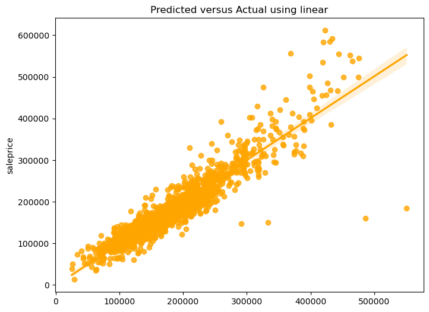

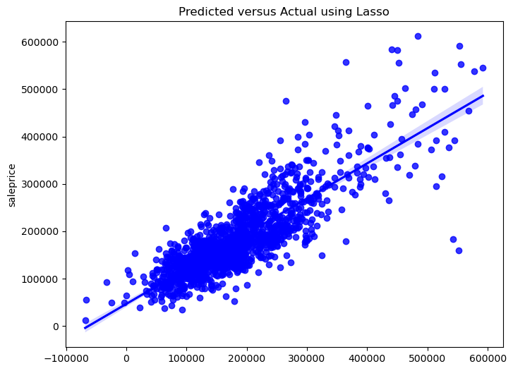

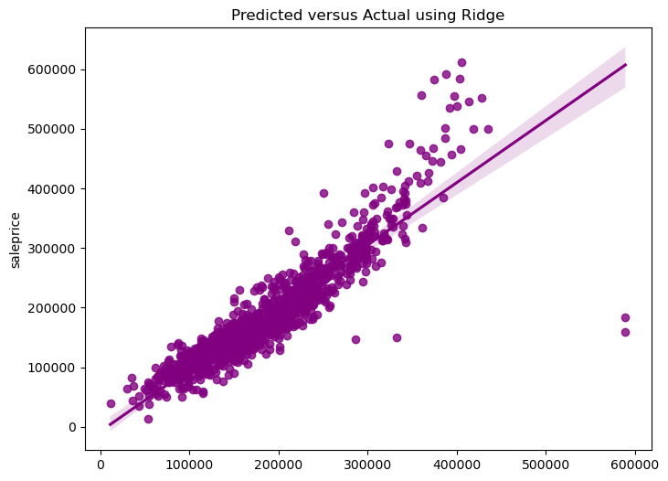

```python
lasso_params = {'alpha':[0.02, 0.024, 0.025, 0.026, 0.03]}
ridge_params = {'alpha':[200, 230, 250,265, 270, 275, 290, 300, 500]}

models2 = {'linear': LinearRegression(),
           'Lasso': GridSearchCV(Lasso(max_iter=5000, tol=7.571e+10),
                               param_grid=lasso_params),
           'Ridge': GridSearchCV(Ridge(),
                               param_grid=ridge_params)}
test_grid = test_modeling(X_en_sc, y, models2, test_size=0.3)
test_grid = pd.DataFrame(test_grid)
test_grid.T
```

1. Using default parameters:

|  | 0 | 1 | 2 |
| --- | --- | --- | --- |
| model | linear | Lasso | Ridge |
| train_score | 0.856431 | 0.858622 | 0.858446 |
| test_score | -14679287657531057373184.0 | 0.874761 | 0.878549 |
| train_mse | 30327.48753 | 30095.241256 | 30113.94977 |
| test_mse | 9367196494531670.0 | 27360.646185 | 26943.73112 |
| cross_val_train | [-2.4129210754081338e+22, -1.0466450364365913e... | [0.855138268973322, 0.8087140319643851, 0.8800... | [0.8589819243744883, 0.8123254450559774, 0.880... |
| cross_val_test | [0.8808240715473872, -1.9002917495644074e+19, ... | [0.8812319320363553, 0.9127710270476118, 0.885... | [0.8897482797705849, 0.9235869472351452, 0.883... |
| scores_mean_train | -7441929465816225415168.0 | 0.805318 | 0.807843 |
| scores_std_train | 9169844694024518107136.0 | 0.069651 | 0.070192 |
| scores_mean_test | -1208395838795059560448.0 | 0.889266 | 0.894838 |
| scores_std_test | 2169032894386159484928.0 | 0.020955 | 0.021579 |

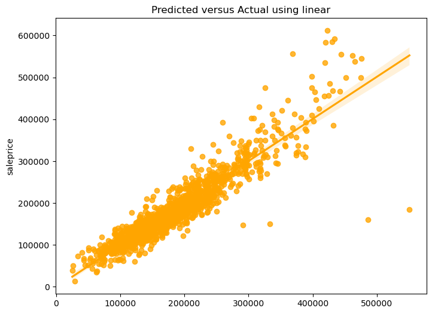

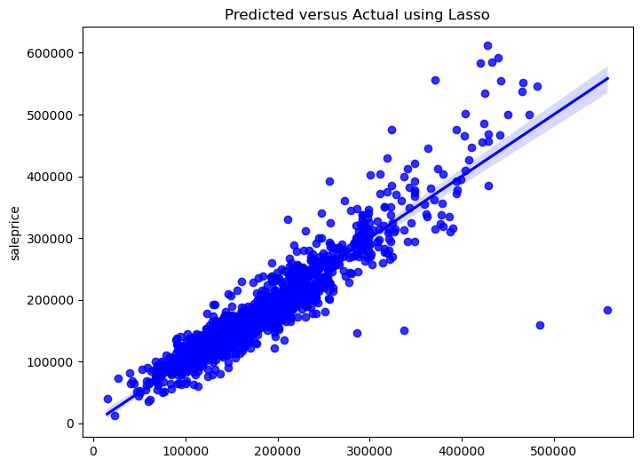

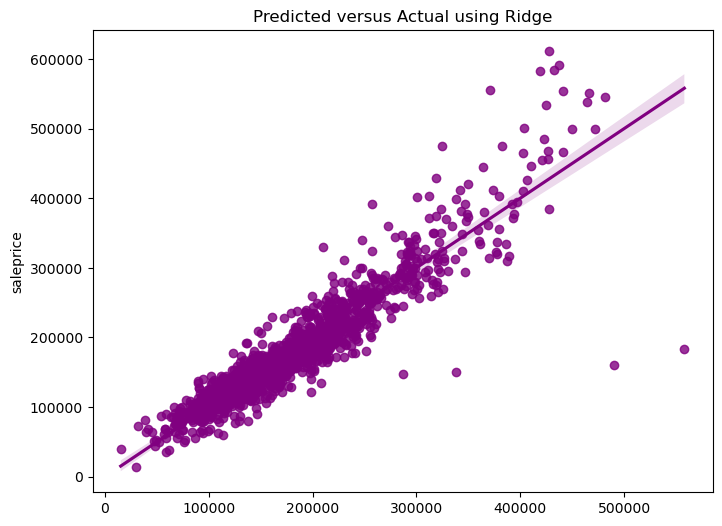

```python
#'logreg': LogisticRegression(max_iter=2000
models = {'linear': LinearRegression(),
         'Lasso': Lasso(max_iter=5000),
         'Ridge': Ridge()}
test_with_three = test_modeling(X_en_sc, y, models, test_size=0.3)
test_with_three = pd.DataFrame(test_with_three)
test_with_three.T
```

### Summary and Conclusions

As seen from the table above, Ridge regularization with 70% of the train datasets yields an RMSE of 26020.56. To further improve the accuracy of the model, it is recommended to select highly correlated features from both the categorical and numerical parts of the dataset. Additionally, adding more regression types such as Polynomial could potentially yield even better results. By taking these steps, the model will become a more reliable indicator for predicting future property prices.